# Through the keyhole of #hashCode into JVM

2017-04-10

## no warranty

## ToC

## Associative array / Dictionary / Map

[figure not shown]

```java
int hash =  hash( key );
int index = Math.abs( hash )
       % keys.length;
```

## javadoc:

### java.lang.Object

```java
public int hashCode()
```

Returns a hash code value for the object. This method is supported for the benefit of hash tables such as those provided by **HashMap**.

[https://docs.oracle.com/javase/8/docs/api/java/lang/Object.html](https://docs.oracle.com/javase/8/docs/api/java/lang/Object.html#hashCode--)

## Write down ( Alex, +79… )

[figure not shown]

## Search / insert complexity

```java
String key = "Alex";

int index = Math.abs( key.hashCode() )
     % keys.length;

if ( key.equals( keys[index] ) )
    return values[index];

return null;
```

complexity → **O( 1 )**

## Contract of hashCode

- consitency & persistence

Whenever it is invoked on the same object more than once during an execution of a Java application, the hashCode method must *consistently* return the same integer, provided no information used in equals comparisons on the object is modified.

[https://docs.oracle.com/javase/8/docs/api/java/lang/Object.html](https://docs.oracle.com/javase/8/docs/api/java/lang/Object.html#hashCode--)

## hashCode contract violation

[figure not shown]

## Collisions

[figure not shown]

## Chaining

[figure not shown]

complexity → **O( N )**

## Open Addressing

[figure not shown]

## Open Addressing

[figure not shown]

complexity → **O( N )**

## hashCode - function of object content

```java
String s1 = new String("java");
String s2 = new String("java");

assert s1.hashCode() == s2.hashCode(); // true

Integer i1 = new Integer(42);
Integer i2 = new Integer(42);

assert i1.hashCode() == i2.hashCode(); // true
```

## Polynomial hashCode

\[ hashCode = \sum_{k=0}^{n} {31^{n-k} \cdot property_k} \]

\[ equals \Rightarrow \] \[ this.property_k == that.property_k , \] \[ \forall k \in [0, n] \]

## String.hashCode()

```java
public final class String {
    private final char value[];
    private int hash;

    public int hashCode() {
        int h = hash;
        if (h == 0 && value.length > 0) {
            char val[] = value;

            for (int i = 0; i < value.length; i++)
                h = 31 * h + val[i];

            hash = h;
        }
        return h;
    }
}
```

## java v.1.1.1 - String.hashCode()

```java
public int hashCode() {
    int h = 0;
    int off = offset;
    char val[] = value;
    int len = count;

    if (len < 16) {
        for (int i = len ; i > 0; i--) {
            h = (h * 37) + val[off++];
        }
    } else {
        // only sample some characters
        int skip = len / 8;
        for (int i = len ; i > 0; i -= skip, off += skip) {
            h = (h * 39) + val[off];
        }
    }
    return h;
}
```

## 31 : Detective story

- 1997-04-17 (!!!): [java bug #4045622](http://bugs.java.com/bugdatabase/view_bug.do?bug_id=4045622)
  - All of the words and phrasesin Merriam-Webster's 2nd Int'l Dictionary (311_141 strings, avg length: 10 chars).
  - All of the strings in `/bin/*`, `/usr/bin/*`, `/usr/lib/*`, `/usr/ucb/*` & `/usr/openwin/bin/*` (66_304 strings, avg length: 21 chars).
  - A list of URLs gathered by a web-crawler that ran for several hours last night (28_372 strings, avg length 49 characters).

polynomial of 31, 33, 37 → min. avg collision length

## String.hashCode is the part of public API

```java
public final class String {
  /**
   * Returns a hash code for this string. The hash code
   * for a String object is computed as
   *
   * s[0]*31^(n-1) + s[1]*31^(n-2) + ... + s[n-1]
   *
   * using int arithmetic, where s[i]
   * is the ith character of the string,
   * n is the length of the string,
   * and ^ indicates exponentiation.
   * (The hash value of the empty string is zero.)
   *
   * @return  a hash code value for this object.
   */
    public int hashCode() {        ...      }
}
```

## it might be found…

```java
assert "Aa".hashCode()
  == "BB".hashCode();
```

\[ 31 \cdot c_0 + c_1 = \] \[ = 31 \cdot (c_0 - 1) + (c_1 + 31) \]

**`username`** ⟹ 499_331  
variants of collision

## Java Microbenchmark Harness

http://openjdk.java.net/projects/code-tools/jmh/

## JMH :: "username" collisions :: benchmark

```java
@State(Scope.Benchmark)
public class MapPerfTest {

  Map map;
  String[] keys;

  @Setup
  public void setup() { ..... }

@Benchmark @Threads( 1 )
public Map fillMap() {
  for (String key : keys)
    map.put(key, key);

  return map;
}
}
```

## JMH :: "username" collisions :: benchmark

```java
@BenchmarkMode(Mode.AverageTime)
@Warmup(iterations = 5, time = 5, timeUnit = SECONDS)
@Measurement(iterations = 5, time = 5, timeUnit = SECONDS)
@State(Scope.Benchmark)
public class MapPerfTest {

  Map map;
  String[] keys;

  @Setup
  public void setup() { ... }

  @Benchmark @Threads( 1 )
  public Map fillMap() {
    // ...
  }
}
```

## JMH :: "username" collisions :: benchmark

```java
@BenchmarkMode(Mode.AverageTime)
@Warmup(iterations = 5, time = 5, timeUnit = SECONDS)
@Measurement(iterations = 5, time = 5, timeUnit = SECONDS)
@State(Scope.Benchmark)
public class MapPerfTest {

  Map map;
  String[] keys;

  @Setup
  public void setup() { ... }

  @Benchmark @Threads( 1 )
  public Map fillMap() {
    // ...
  }
}
```

## JMH :: "username" collisions :: benchmark

```java
@BenchmarkMode(Mode.AverageTime)
@Warmup(iterations = 5, time = 5, timeUnit = SECONDS)
@Measurement(iterations = 5, time = 5, timeUnit = SECONDS)
@State(Scope.Benchmark)
public class MapPerfTest {

  Map map;
  String[] keys;

  @Setup
  public void setup() { ... }

  @Benchmark @Threads( 1 )
  public Map fillMap() {
    // ...
  }
}
```

## JMH :: "username" collisions :: benchmark

```java
@State(Scope.Benchmark)
public class MapPerfTest {

  @Param( {"1", "1000", "10000", "100000", "200000"})
  int size;
  Map map;
  String[] keys;

@Setup
public void setup() {
  map = new HashMap<String, String>( size );
  keys = loadUsernameCollisionsFromFile( size );
}
  @Benchmark @Threads( 1 )
  public Map fillMap() { ... }

}
```

## "username" collisions

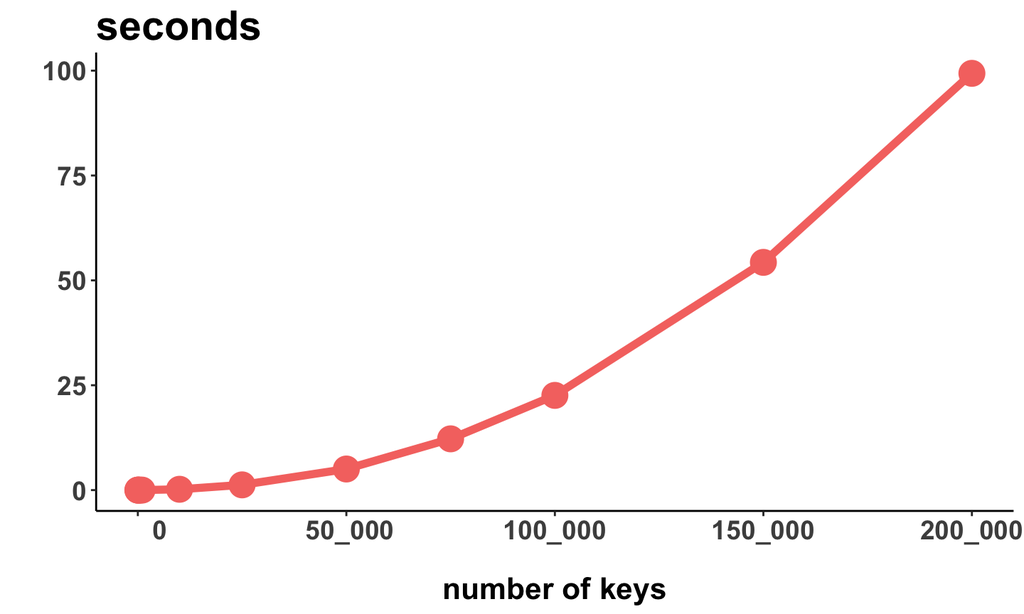

## extra function is required

## Extra function: compareTo

[figure not shown]

complexity → **O( log( N ) )**

## Chaining & Red-Black-Tree

[figure not shown]

## "username" collisions

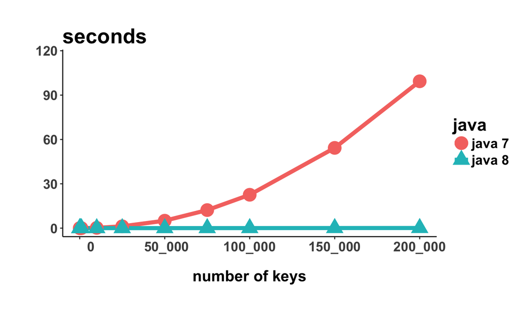

## "username" collisions :: 500x zoom-in

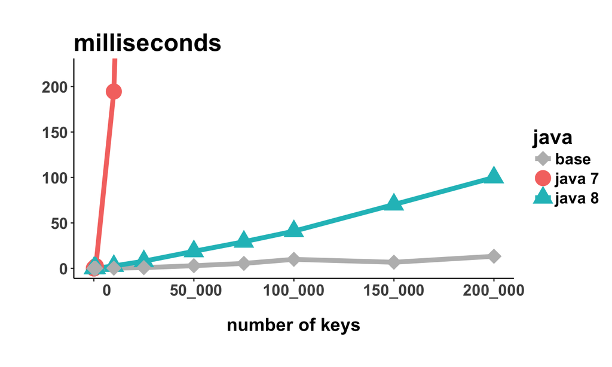

## "username" collisions :: Comparable

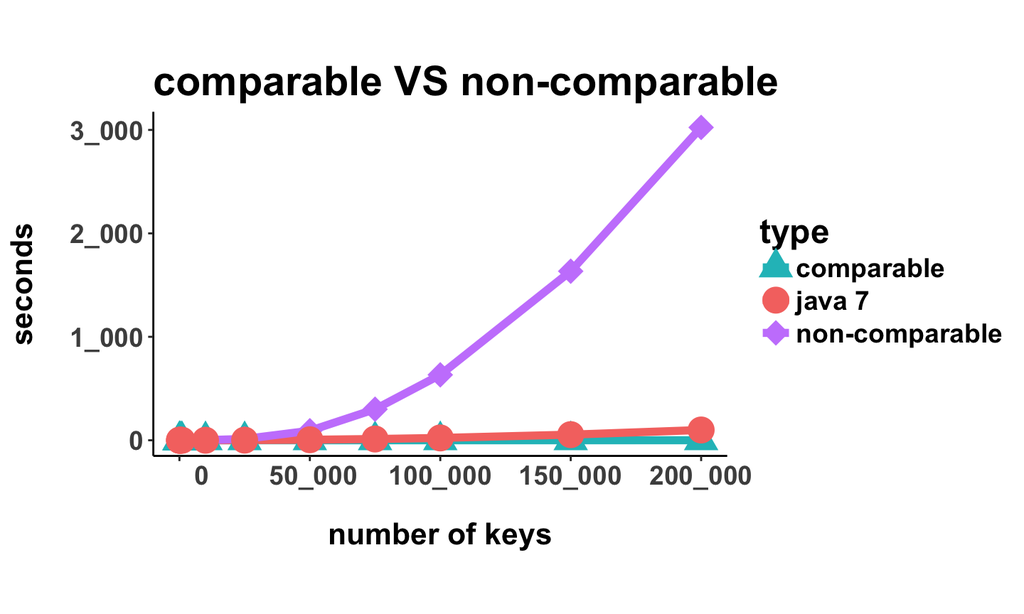

## Object.hashCode is a leaked abstraction

## Urban Legend

```java
public int hashCode(){
  return &this;
}
```

## Urban Legend: the source

### java.lang.Object

```java
public int hashCode()
```

This is typically implemented by converting the internal address of the object into an integer.

[https://docs.oracle.com/javase/8/docs/api/java/lang/Object.html](https://docs.oracle.com/javase/8/docs/api/java/lang/Object.html#hashCode--)

## Address of an object ?

## native method

```java
  package java.lang;

  public class Object {

      // ............

      public native int hashCode();
  }
```

## sun.misc.Unsafe

```java
public native long allocateMemory(long bytes);

public native void freeMemory(long address);

public native void setMemory(Object o,
    long offset, long bytes, byte value);

public native long getLong(Object o, long offset);

public native void putLong(Object o,
    long offset, long x);

// etc ...
```

## Unsafe :: address of an object

```java
private static Unsafe fetchUnsafe() {
  final Field field =
      Unsafe.class.getDeclaredField( "theUnsafe" );
  field.setAccessible( true );
  return (Unsafe) field.get( null );
}

public long getAddress(final Object object) {
  checkVMBooleanOption("UseCompressedOops", false);

  Unsafe unsafe = fetchUnsafe();

  return unsafe.getLong( new Object[]{ object },
      unsafe.arrayBaseOffset( Object[].class ));
}
```

## Unsafe :: address of an object

```java
private static Unsafe fetchUnsafe() {
  final Field field =
      Unsafe.class.getDeclaredField( "theUnsafe" );
  field.setAccessible( true );
  return (Unsafe) field.get( null );
}

public long getAddress(final Object object) {
  checkVMBooleanOption("UseCompressedOops", false);

  Unsafe unsafe = fetchUnsafe();

  return unsafe.getLong( new Object[]{ object },
      unsafe.arrayBaseOffset( Object[].class ));
}
```

## Unsafe :: address of an object

```java
private static Unsafe fetchUnsafe() {
  final Field field =
      Unsafe.class.getDeclaredField( "theUnsafe" );
  field.setAccessible( true );
  return (Unsafe) field.get( null );
}

public long getAddress(final Object object) {
  checkVMBooleanOption("UseCompressedOops", false);

  Unsafe unsafe = fetchUnsafe();

  return unsafe.getLong( new Object[]{ object },
      unsafe.arrayBaseOffset( Object[].class ));
}
```

⟹ -XX:-UseCompressedOops

## Java Object Layout

```java
Object theObject = new Object();

VirtualMachine vm = VM.current();

long address = vm.addressOf( theObject );

long size = vm.sizeOf( theObject );
```

http://openjdk.java.net/projects/code-tools/jol/

## JOL : sizeOf( new Pair() )

```java
class Pair<F, S> {
  F first;
  S second;
}
```

```java
class Pair2<F, S> {
  F first;
  S second;
  int hashCode;
}
```

## -XX:+UseCompressedOops & heap < 32Gb

`-XX:+UseCompressedOops`

`24 b`

`24 b`

```java
class Pair<F, S> {
  F first;
  S second;
}
```

```java
class Pair2<F, S> {
  F first;
  S second;
  int hashCode;
}
```

## -XX:+UseCompressedOops & heap < 32Gb

`-XX:+UseCompressedOops`

`24 b`

`24 b`

```java
class Pair<F, S> {
  F first;
  S second;
}
```

```java
class Pair2<F, S> {
  F first;
  S second;
  int hashCode;
}
```

```
Pair object internals:
 OFFSET  SIZE   TYPE DESCRIPTION
      0    12        (object header)
     12     4 Object Pair.first
     16     4 Object Pair.second
     20     4      (loss due to the next
                     object alignment)
```

## -XX:-UseCompressedOops OR heap ≥ 32Gb

`-XX:-UseCompressedOops`

`32 b`

`40 b`

```java
class Pair<F, S> {
  F first;
  S second;
}
```

```java
class Pair2<F, S> {
  F first;
  S second;
  int hashCode;
}
```

## -XX:-UseCompressedOops OR heap ≥ 32Gb

`-XX:-UseCompressedOops`

`32 b`

`40 b`

```java
class Pair<F, S> {
  F first;
  S second;
}
```

```java
class Pair2<F, S> {
  F first;
  S second;
  int hashCode;
}
```

```
Pair2 object internals:
 OFFSET  SIZE   TYPE DESCRIPTION
      0    16        (object header)
     16     4    int Pair2.hashCode
     20     4      (alignment/padding gap)
     24     8 Object Pair2.first
     32     8 Object Pair2.second
```

## -XX:-UseCompressedOops OR heap ≥ 32Gb

`-XX:-UseCompressedOops`

`32 b`

`40 b`

```java
class Pair<F, S> {
  F first;
  S second;
}
```

```java
class Pair2<F, S> {
  F first;
  S second;
  int hashCode;
}
```

```
Pair2 object internals:
 OFFSET  SIZE   TYPE DESCRIPTION
      0    16        (object header)
     16     4    int Pair2.hashCode
     20     4      (alignment/padding gap)
     24     8 Object Pair2.first
     32     8 Object Pair2.second
```

## Address and hashCode

[figure not shown]

```
-XX:
hashCode=4
```

## Follow the address of the object

```java
final Object theObject = new Object();
final long initialAddress = getAddress( theObject );

List gcKeeper = new ArrayList();
gcKeeper.add( theObject );

long currentAddress = initialAddress;
while (initialAddress == currentAddress) {
    Object o = new Object();

    gcKeeper.add( o );

    currentAddress = getAddress( theObject );
}
```

`-Xms256m -Xmx256m -XX:+UseSerialGC`

## Follow the address of the object

```java
final Object theObject = new Object();
final long initialAddress = getAddress( theObject );

List gcKeeper = new ArrayList();
gcKeeper.add( theObject );

long currentAddress = initialAddress;
while (initialAddress == currentAddress) {
    Object o = new Object();

    gcKeeper.add( o );

    currentAddress = getAddress( theObject );
}
```

`-Xms256m -Xmx256m -XX:+UseSerialGC`

## Follow the address of the object

```java
final Object theObject = new Object();
final long initialAddress = getAddress( theObject );

List gcKeeper = new ArrayList();
gcKeeper.add( theObject );

long currentAddress = initialAddress;
while (initialAddress == currentAddress) {
    Object o = new Object();

    gcKeeper.add( o );

    currentAddress = getAddress( theObject );
}
```

`-Xms256m -Xmx256m -XX:+UseSerialGC`

## Follow the address of the object

```java
final Object theObject = new Object();
final long initialAddress = getAddress( theObject );

List gcKeeper = new ArrayList();
gcKeeper.add( theObject );

long currentAddress = initialAddress;
while (initialAddress == currentAddress) {
    Object o = new Object();

    gcKeeper.add(o);

    currentAddress = getAddress( theObject );
}
```

`-Xms256m -Xmx256m -XX:+UseSerialGC`

## demo

## Weak generational hypothesis

[figure not shown]

**Generational GCs**: Serial, Parallel, CMS and *even* G1

## Follow the address of the object together with GC

```java
final Object theObject = new Object();
final long initialAddress = getAddress( theObject );

List gcKeeper = new ArrayList();
gcKeeper.add( theObject );

long currentAddress = initialAddress;
while (initialAddress == currentAddress) {
    Object o = new Object();

    gcKeeper.add(o);

    currentAddress = getAddress( theObject );
}
```

`-XX:+PrintGCDetails -Xmx256m -XX:+UseSerialGC`

## GC is more than just a garbage collection

[figure not shown]

## Follow the hashcode

```java
final Object theObject = new Object();
final long initialHashCode = theObject.hashCode();

List gcKeeper = new ArrayList();
gcKeeper.add(theObject);

long currentHashCode = initialHashCode;
while (initialHashCode == currentHashCode) {
    Object o = new Object();

    gcKeeper.add(o);

    currentHashCode = theObject.hashCode();
}
```

`-Xms256m -Xmx256m -XX:+UseSerialGC`

## demo

## Hidden property

```java
package java.lang;

public class Object {

    // other methods

    public native int hashCode();

}
```

## Object memory dump

[figure not shown]

Intel X86: Little Endian

## How many could fit in heap ?

`-Xmx256m`

```java
long freeMemory =
  Runtime.getRuntime().freeMemory();

= 239_942_568

freeMemory / vm.sizeOf( new Object() )

= 14_996_410
```

## Collisions boundary

```java
final int maxCollisions = 1;
final int[] collisions = new int[maxCollisions];

final List gcKeeper = new ArrayList();
final HashIntSet uniqueHashCodes = HashIntSets.newMutableSet();

for (int collisionNo = 0; collisionNo < maxCollisions; ) {
    final Object obj = new Object();
    gcKeeper.add(obj);

    int hashCode = obj.hashCode();

    if ( ! uniqueHashCodes.add(hashCode) )
        collisions[collisionNo++] = hashCode;
}
```

```
-Xms256m -Xmx256m -XX:+UseSerialGC -XX:
hashCode=4
```

## demo

## Young generation

```
eden space 65536K, 2% used
[0x000000012a700000, 0x000000012a8db400, 0x000000012e700000)
Оbject reallocated: 0x12A8109F0 -> 0x12E7200F8
```

```java
65536K / vm.sizeOf( new Object() )

= 4_194_304
```

## hashCode space

32bit → 22bit

```
=
4_194_304
```

unique values

## Collisions boundary - results

```
after 1,331,460 allocation:
hash code collision at 0x3055A990
hash code collision at 0x3055A9A0
hash code collision at 0x3055A9B0
hash code collision at 0x3055A9C0
hash code collision at 0x3055A9D0
hash code collision at 0x3055A9E0
hash code collision at 0x3055A9F0
```

## hashCode → address → → memory allocation

## Memory allocation

```java
public interface Allocator {
    long malloc(long size);
}

class SimpleAllocator implements Allocator {
    private long memoryPointer;

    @Override
    public long malloc(long size) {
        long old = memoryPointer;
        memoryPointer += size;
        return old;
    }
}
```

## Let's fix malloc: SyncAllocator

```java
class SyncAllocator implements Allocator {
    private long memoryPointer;

    @Override
    public synchronized long malloc(long size) {
        long old = memoryPointer;
        memoryPointer += size;
        return old;
    }
}
```

## SyncAllocator Performance Benchmark

```java
@Benchmark @Threads( 4 )
public long syncAllocator() {
    return syncAllocator.malloc( 16 );
}
```

## SyncAllocator Performance Benchmark

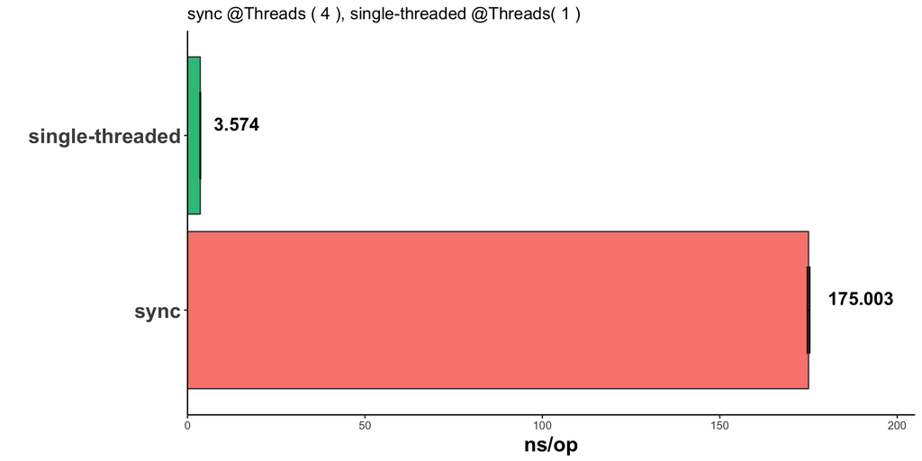

[figure not shown]

## Can make it better ?

## Compare-and-Set

## CAS Allocator

```java
class CASAllocator implements Allocator {
    private final AtomicLong memoryPointer =
        new AtomicLong();

    @Override
    public long malloc(long size) {
        return memoryPointer.getAndAdd( size );
    }
}
```

## Allocators Performance Benchmark

```java
@Benchmark @Threads( 4 )
public long casAllocator() {
    return casAllocator.malloc( 16 );
}
```

## Allocators Performance Benchmark

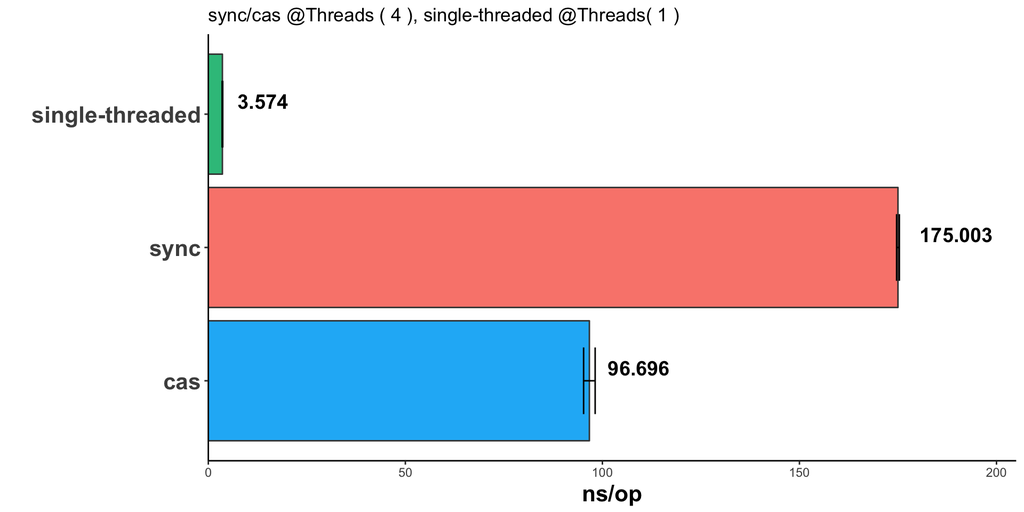

[figure not shown]

## Java Allocation

```java
@Benchmark @Threads( 4 )
public Object javaAllocation() {
    return new Object();
}
```

## Java Allocation

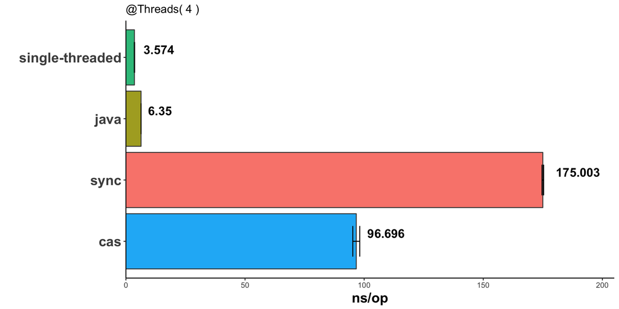

[figure not shown]

## Can make it even better ?

## hashCode distribution over threads

## hashCode distribution : Expectations

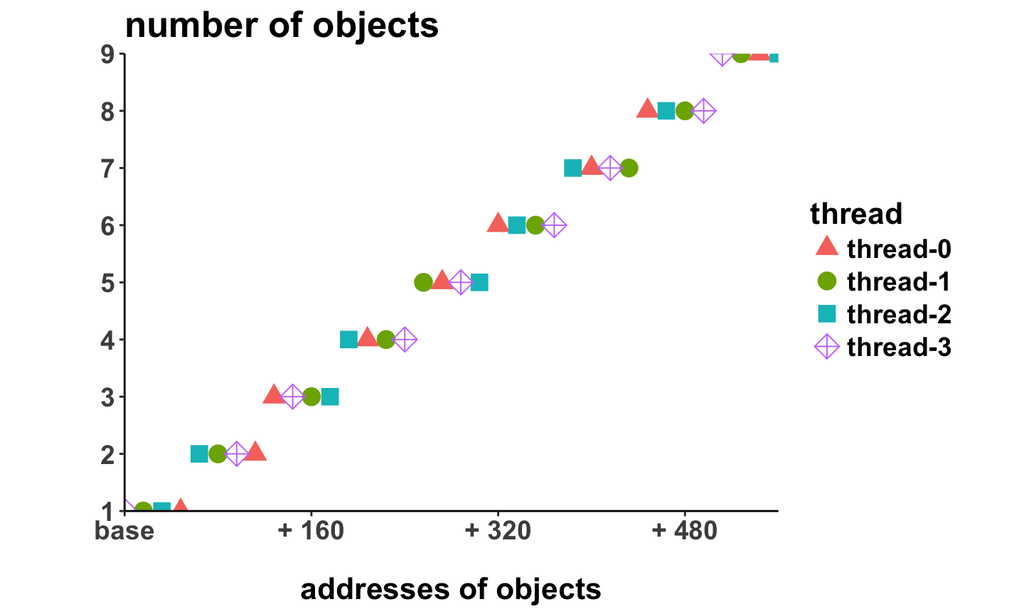

## hashCode distribution over 4 threads

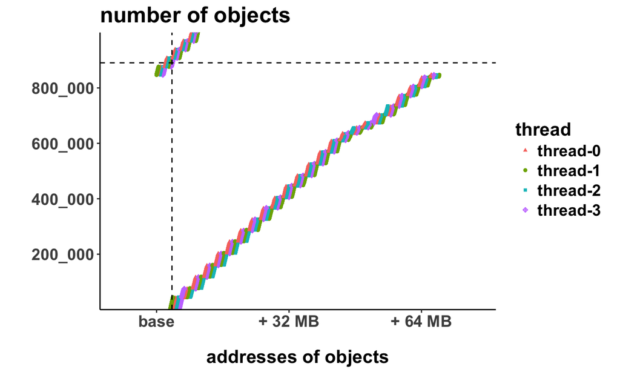

## The good news

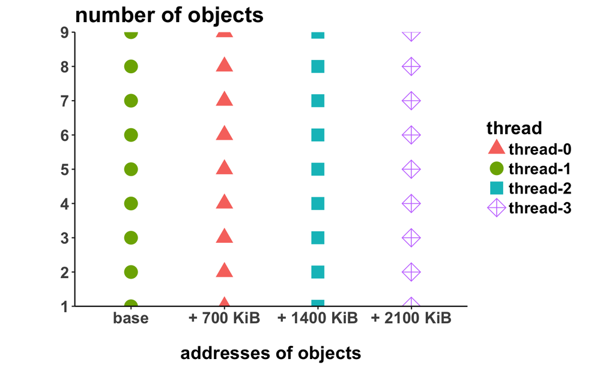

## Let's grab **HUGE** pieces of memory !

```java
public class TLABLikeAllocator implements Allocator {
  private static final long SIZE = 1024L * 1024L;

  private final AtomicLong memoryPointer = new AtomicLong();
  private final ThreadLocal<AddressHolder> threadLocal =
       ThreadLocal.withInitial(() -> new AddressHolder());

  public long malloc( long size ) {
    AddressHolder addressHolder = threadLocal.get();
    while( true ) {
      if (addressHolder.value + size <= addressHolder.maxValue) {
          long old = addressHolder.value;
          addressHolder.value += size;
          return old;
      }

      long value = memoryPointer.getAndAdd( SIZE );
      addressHolder.value = value;
      addressHolder.maxValue = value + SIZE;
    }
  }
}
```

## Let's grab **HUGE** pieces of memory !

```java
public class TLABLikeAllocator implements Allocator {
  private static final long SIZE = 1024L * 1024L;

  private final AtomicLong memoryPointer = new AtomicLong();
  private final ThreadLocal<AddressHolder> threadLocal =
       ThreadLocal.withInitial(() -> new AddressHolder());

  public long malloc( long size ) {
    AddressHolder addressHolder = threadLocal.get();
    while( true ) {
      if (addressHolder.value + size <= addressHolder.maxValue) {
          long old = addressHolder.value;
          addressHolder.value += size;
          return old;
      }

      long value = memoryPointer.getAndAdd( SIZE );
      addressHolder.value = value;
      addressHolder.maxValue = value + SIZE;
    }
  }
}
```

## Let's grab **HUGE** pieces of memory !

```java
public class TLABLikeAllocator implements Allocator {
  private static final long SIZE = 1024L * 1024L;

  private final AtomicLong memoryPointer = new AtomicLong();
  private final ThreadLocal<AddressHolder> threadLocal =
       ThreadLocal.withInitial(() -> new AddressHolder());

  public long malloc( long size ) {
    AddressHolder addressHolder = threadLocal.get();
    while( true ) {
      if (addressHolder.value + size <= addressHolder.maxValue) {
          long old = addressHolder.value;
          addressHolder.value += size;
          return old;
      }

      long value = memoryPointer.getAndAdd( SIZE );
      addressHolder.value = value;
      addressHolder.maxValue = value + SIZE;
    }
  }
}
```

## Allocators Performance Benchmark

```java
@Benchmark @Threads( 4 )
public long tlabAllocator() {
    return tlabAllocator.malloc( 16 );
}
```

## Allocators Performance Benchmark

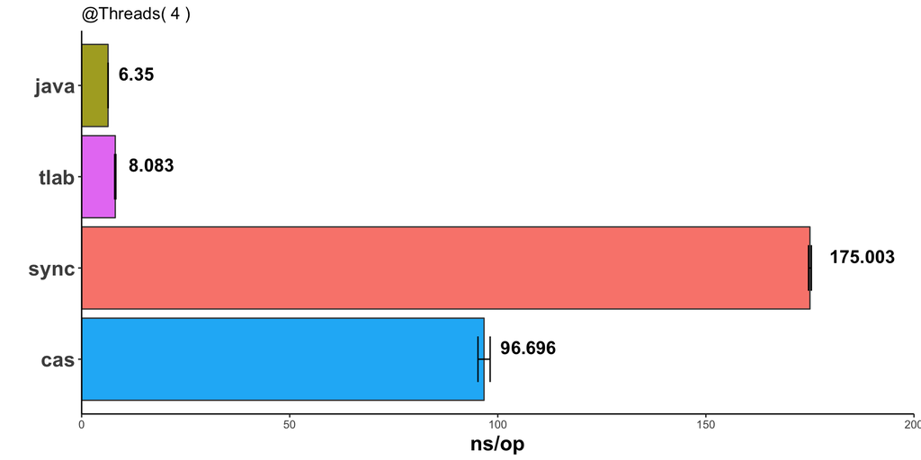

[figure not shown]

## Thread Local Allocation Buffer

[figure not shown]

## Thread Local Allocation Buffer

[figure not shown]

## Cost of TLAB

```java
@Benchmark @Threads( 4 )
public Object allocate() {
   return new Object();
}
```

-XX: +UseTLAB vs -XX: -UseTLAB

## Cost of TLAB

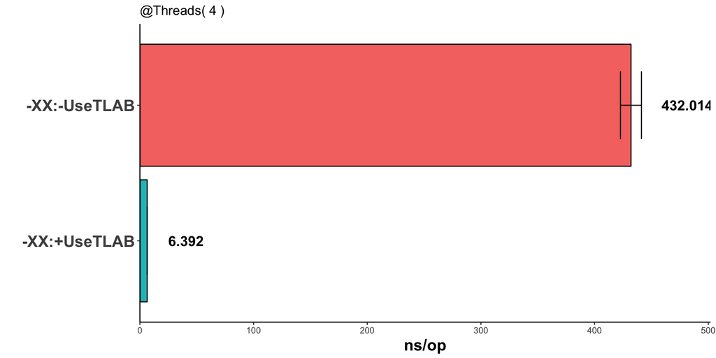

[figure not shown]

## What if it is a Random ?

## Birthday problem

\[ n \approx \sqrt{2 d \cdot ln({1\over{1 - p_{uniq}}}) }\]

using \[ \ d = 2^{32}, \ p = 0.5 \Rightarrow \] \[ n \approx 77162 \]

## -XX:hashCode

| -XX:hashCode=k | Type |
| --- | --- |
| 0 | [Park-Miller RNG](https://en.wikipedia.org/wiki/Lehmer_random_number_generator) |
| 1 | fn(address of object, global state) |
| 2 | const 1 |
| 3 | incremental counter |
| 4 | address of object |
| 5 | [Marsaglia xor-shift RNG](https://en.wikipedia.org/wiki/Xorshift) **by default** in java 8 |

## Memory dump of object -XX:hashCode=5

[figure not shown]

## Distribution of 10 millions objects in 10 threads

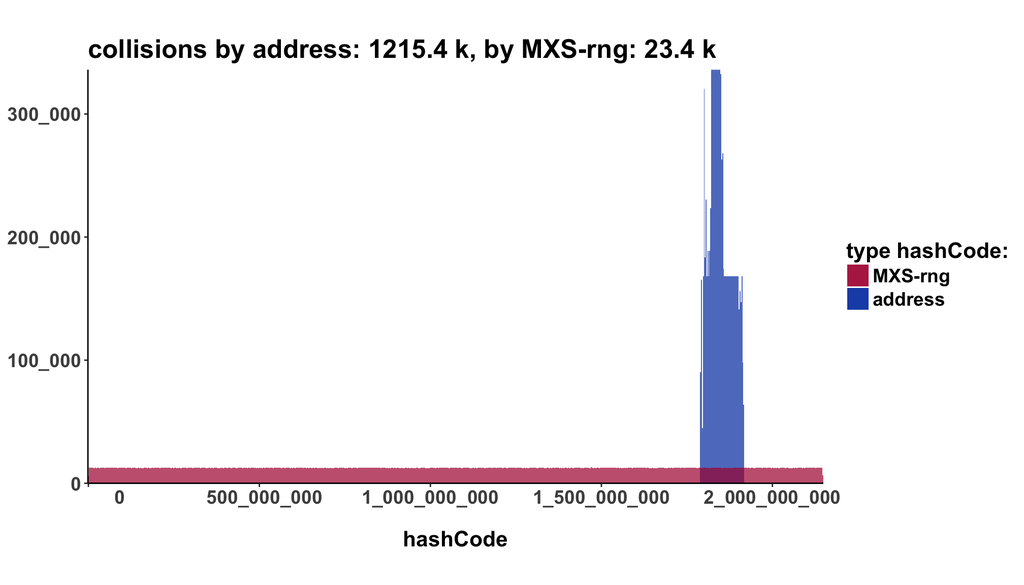

## has hashCode been calculated ?

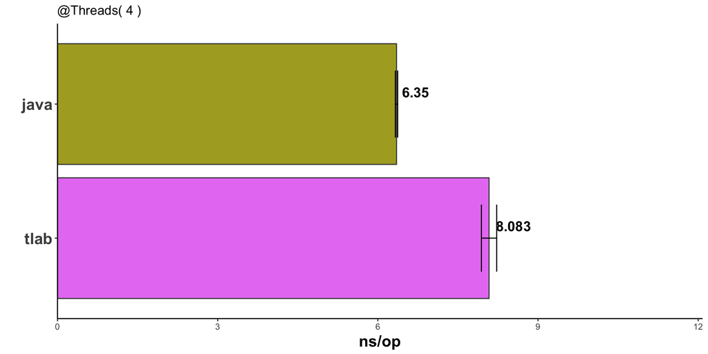

[figure not shown]

## Object.hashCode() benchmark

```java
Object theObject = new Object();

@Benchmark @Threads( 4 )
public Object javaHashCode() {
    Object object = new Object();
    object.hashCode();
    return object;
}

@Benchmark @Threads( 4 )
public int readHashCode() {
    return theObject.hashCode();
}
```

## Object.hashCode() benchmark

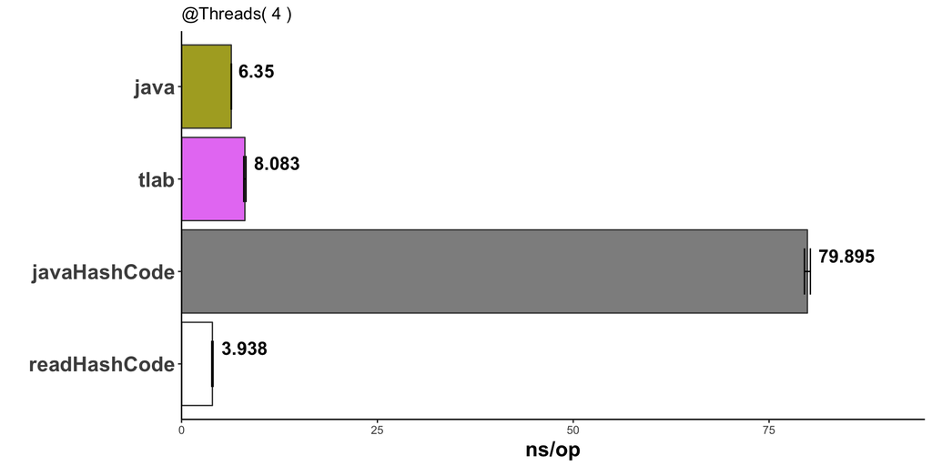

[figure not shown]

## Memory dump of object right after creation

```java
Object object = new Object();

dump( object );
```

[figure not shown]

## monitor

```java
public class Object {
  //// other methods
  public final native void notify();

  public final native void wait(long timeout)
      throws InterruptedException;
}
```

## Biased Locking

[figure not shown]

## Biased Locking demo:

```java
synchronized (object) {
    object.notifyAll();
}
dump( object );
```

[figure not shown]

## StringBufferPerfTest

```java
StringBuffer buf = new StringBuffer();

@Benchmark @Thread(1)
public String bufferToString() {
  return buf.toString();
}
```

`-XX:+UseBiasedLocking` VS `-XX:-UseBiasedLocking`

`-XX:BiasedLockingStartupDelay=0`

## StringBufferPerfTest

```java
StringBuffer buf = new StringBuffer();

@Benchmark @Thread(1)
public String bufferToString() {
  return buf.toString();
}
```

`-XX:+UseBiasedLocking` VS `-XX:-UseBiasedLocking`

`-XX:BiasedLockingStartupDelay=0`

## StringBufferPerfTest results

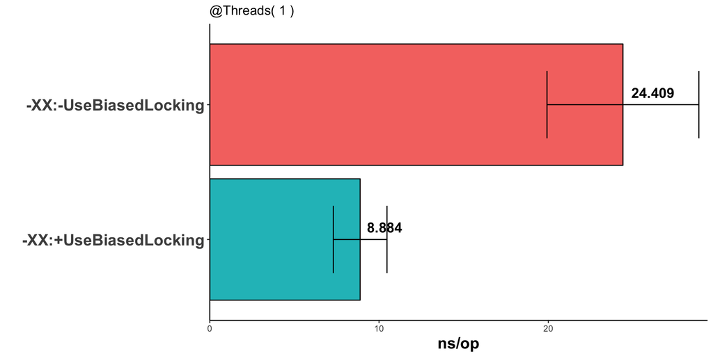

[figure not shown]

## identityHashCode

```java
StringBuffer buf = new StringBuffer();
StringBuffer bufferWithIdHashCode =
    new StringBuffer();

@Setup
public void setup(Blackhole bh) {
    bh.consume( System.identityHashCode(
        bufferWithIdHashCode ) );
}

@Benchmark  @Thread(1)
public String bufferWithIdHashCode() {
  return bufferWithIdHashCode.toString();
}

@Benchmark @Thread(1)
public String buffer() {
  return buf.toString();
}
```

## identityHashCode

```java
StringBuffer buf = new StringBuffer();
StringBuffer bufferWithIdHashCode =
   new StringBuffer();

@Setup
public void setup(Blackhole bh) {
    bh.consume( System.identityHashCode(
        bufferWithIdHashCode ) );
}

@Benchmark  @Thread(1)
public String bufferWithIdHashCode() {
  return bufferWithIdHashCode.toString();
}

@Benchmark  @Thread(1)
public String buffer() {
  return buf.toString();
}
```

## identityHashCode results

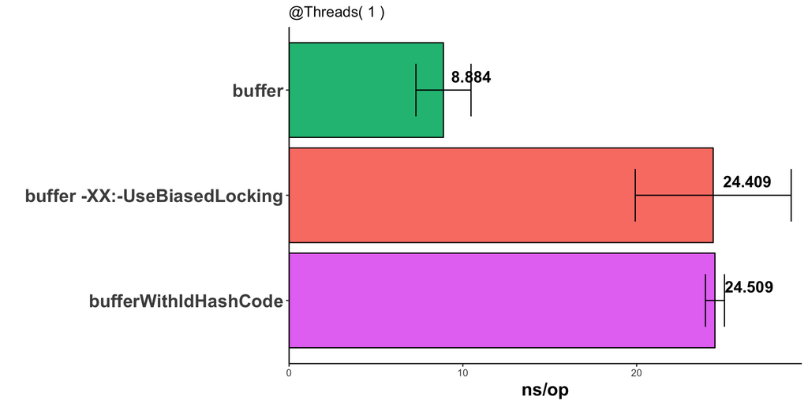

[figure not shown]

## Revoke Biased Locking:

```java
int idHashCode
  = System.identityHashCode( object );

dump( object );
```

[figure not shown]

## Conclusion

- Hash data-structures are the fastest ones
- Override `hashCode` and `equals`
  - and even more implement `compareTo`
  - investigate your hash-functions
- hashCode is not address of object
  - GC, TLAB, don't saturate `identityHashCode`
- **Meten is weten** (Dutch) «Measurement is knowledge»

## Contacts

### slides and examples: github.com/vladimirdolzhenko/hashCodeLegend

### email: vladimir.dolzhenko@ihsmarkit.com

### email: vladimir.dolzhenko@gmail.com

### twitter: [@dolzhenko](https://twitter.com/dolzhenko)

thanks: [@VladimirSitnikv](https://twitter.com/VladimirSitnikv) [@dj_begemot](https://twitter.com/dj_begemot) [@AndreiPangin](https://twitter.com/AndreiPangin) [@gvsmirnov](https://twitter.com/gvsmirnov) [@i_sopov](https://twitter.com/i_sopov)